# Cyclistic Q3 2023 Analysis

Young Kye Kim

2023-10-19

## Preview

This is an analysis of the Q3 usage data of Cyclistic Bike Share Program for 2023. This analysis covers July, August, and September of 2023. Data can be found in raw form [here](https://divvy-tripdata.s3.amazonaws.com/index.html).

## Analysis

The raw data was inspected, cleaned and manipulated for deep analysis in this order:

1. Downloaded each file as CSV and opened on Microsoft Excel.
2. Average length of ride in minutes and days were calculated by subtracting the start time of the ride against the end time of the ride.
3. Negative values for Average Length of ride in minutes were removed.
4. Data was imported to R Studio and columns were inspected and addressed any potential labeling issues.
5. Filtered out data that is less than 1 minute and over 1 day in duration of ride. This to be addressed later in the Addendum section.
6. Reviewed and Analyzed.

#### This is the code used for output

```r
q3_2023_v2 %>%
  group_by(member_casual,day_of_usage) %>%
  summarise(number_of_rides=n(),average_duration=mean(duration_min)) %>%
  arrange(member_casual,day_of_usage)
```

```
## # A tibble: 14 × 4
## # Groups:   member_casual [2]
##    member_casual day_of_usage number_of_rides average_duration
##    <chr>         <ord>                  <int>            <dbl>
##  1 casual        Sunday                145913             25.8
##  2 casual        Monday                 98794             22.5
##  3 casual        Tuesday               103435             20.9
##  4 casual        Wednesday              97400             19.1
##  5 casual        Thursday              108747             19.6
##  6 casual        Friday                135643             21.9
##  7 casual        Saturday              189459             25.0
##  8 member        Sunday                147519             14.9
##  9 member        Monday                164650             12.7
## 10 member        Tuesday               191905             12.8
## 11 member        Wednesday             192895             12.5
## 12 member        Thursday              199797             12.6
## 13 member        Friday                189203             13.3
## 14 member        Saturday              184263             14.6
```

## Graph of Analysis

Here are the graphic visualizations of the above data.

First graph compares the casual rider to members in terms of daily usage. It’s plain to see that while weekend usage is similar, Members tend to use the bikes more during the week while casual members do not.

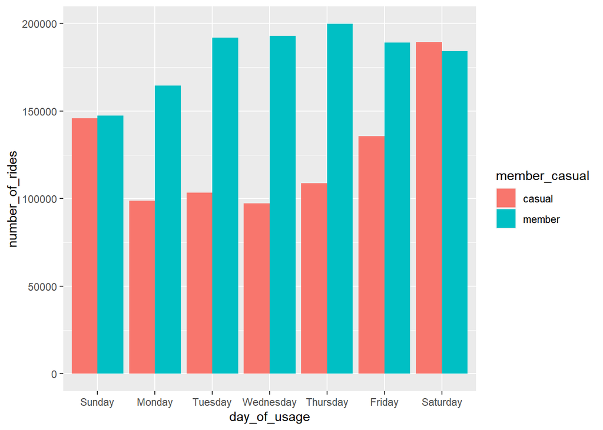

```r
q3_2023_v2 %>%
  group_by(member_casual,day_of_usage) %>%
  summarise(number_of_rides=n(),average_duration=mean(duration_min)) %>%
  arrange(member_casual,day_of_usage) %>%
  ggplot(aes(x=day_of_usage,y=number_of_rides,fill=member_casual))+geom_col(position="dodge")
```

This second graph shows the length of time spent on the borrowed bikes. It shows that casual bikers will borrow for the bike for a longer period of time when they do use it.

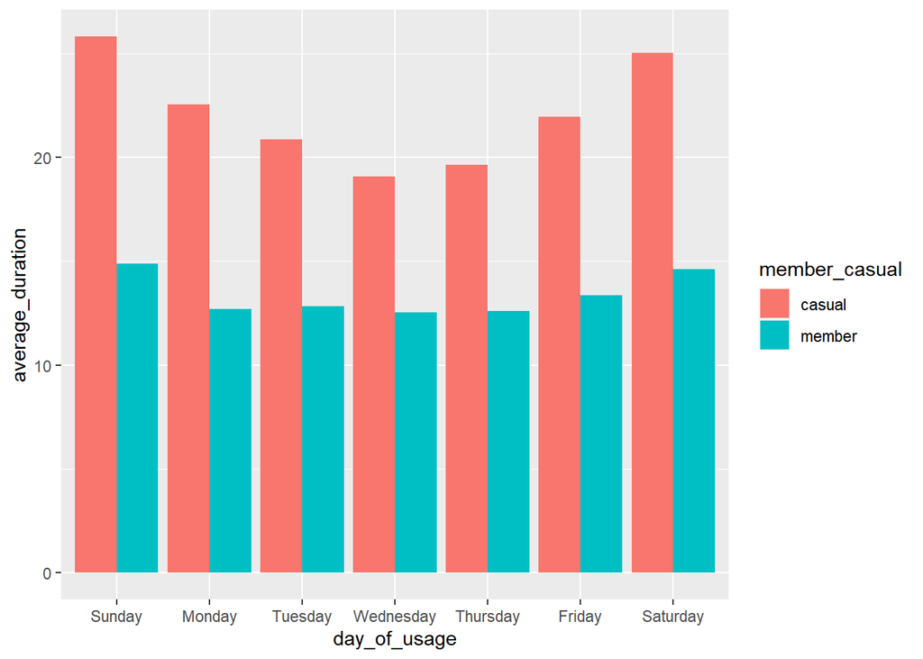

```r
q3_2023_v2 %>%
  group_by(member_casual,day_of_usage) %>%
  summarise(number_of_rides=n(),average_duration=mean(duration_min)) %>%
  arrange(member_casual,day_of_usage) %>%
  ggplot(aes(x=day_of_usage,y=average_duration,fill=member_casual))+geom_col(position="dodge")
```

## Addendum

Let’s address the two abnormalities in the data - 1) bikes being rented for over a day and 2) bikes being rented for less than a minute.

If you remember earlier, I stated that we will address the abnormalities in this section. Let’s dive in.

### Bikes Shared for Over a Day

Refer to Addendum - bikeshare1.xlsx

For July, there were 392 instances of bikes being rented for an average of 4 days and up to 35 days. These were all rented by casual riders of docked bicycles.

For August, there were 366 instances of bikes being rented for an average of 6 days and up to 68 days. These were again rented by casual riders only and for only docked bicycles.

September’s data does not show any information regarding docked bicycles, which were possibly being phased out due to these issues. However, there were 715 instances where a bicycle was rented for over a day by casual riders and 144 instances where a bicycle was rented for over a day by members.

Observing this data, it’s clear to see two things - docked bicycle system probably needs to be addressed, and casual members tend to rent the bike for longer - much longer - than members.

Perhaps a late return fee can be charged to the casual riders as a selling point for annual membership.

### Bikes Shared Less Than a Minute

Refer to Addendum - bikeshare0.xlsx

This might be looked over as irrelevant data, and perhaps it is, but it may also be a good way to think about customer psychology.

In July, there was 8810 instances of less than 30 seconds of usage time form casual riders, while there was 11383 instanes of such behavior from members.

In August, there was 7382 instances from casual riders and 10987 from members.

In September, 5860 instances from casual riders and 8450 from members.

It’s easy to speculate why this happened, and perhaps matching this information to the local area’s weather pattern might reveal more insight, but the information that pops from the available data is that members take advantage of their membership by freely borrowing and canceling their bike.

Depending on the availability of the bikes in the area, this might be cause for concern.

## Observation on Casual vs Members

In the beginning of the project, the question “How do annual members and casual riders use Cyclistic bikes differently?” with the aim of analyzing the consumer behavior of casual riders in order to convert them to annual members. It has been determined that annual members are more profitable than casual members.

Here are the observations and recommendations based on the data analysis.

1. Casual riders tend to ride the bicycle less frequently than the members during the week, but they ride it just as frequently during the weekend.

An incentive provided for annual members during the week - promotions and coupons - may encourage casual riders to consider switching to annual membership.

2. Casual riders ride for longer when they do rent the bikes. Perhaps an increased hourly borrowing rate might encourage the casual riders to convert to an annual plan.
3. Casual riders tend to borrow their bikes for longer, perhaps due to an inconvenient return system for docking bikes. Perhaps a late fee on bikes that aren’t returned within a day can be charged, which may encourage the casual riders to convert to an annual plan as opposed to paying a high fine.
4. Casual riders sign up and cancel frequently, albeit less frequently than the members. This trend must be monitored as members reserving a bike and cancelling it without riding it may cause the system to show a lack of availability of bikes in the area, discouraging casual members from renting the bikes.